# Assignment 6

Wai Zin Linn

#### Due Friday, March 6, 11:59 PM

### 1

Read in, transform, and combine the `obesity-hw.csv` and `education.csv` data sets so that you have two rows for each zip code (one row for each sex), and the columns of data listed below. Remove rows with missing values. Eliminate the data on obesity among children.

You may find that summarizing the data across age cohorts within each zip code and sex (i.e., grouping by zip code and sex) is helpful for setting up this data frame.

- `zip` = zip code
- `sex` = sex (male or female)
- `adult_n` = estimated # of adults (by zip and sex)
- `obese_n` = estimated # of obese adults (by zip and sex)
- `obese_p` = estimated proportion of obese adults (by zip and sex)
- `pct_bach` = % adults (aged 25+, of the given sex by zip) with at least a bachelors degree

Print out the first six rows of the transformed and combined data frame using the function `head()`.

```r
obesity <- read_csv("../../data/obesity-hw.csv")
education <- read_csv("../../data/education.csv")

education<-education%>%
  rename(male = pct_m_bach,
         female = pct_f_bach)

education<-pivot_longer(education,cols=c(male,female),names_to="sex",values_to="pct_bach")

ob1<-obesity%>%
  filter(age != "05-17")%>%
  group_by(zip,sex)%>%
  drop_na()%>%
  summarize(adult_n = sum(pop), obese_n = adult_n*(sum(obese)/sum(bmi)), obese_p = sum(obese_n)/sum(adult_n))%>%
  left_join(education,by=c("zip","sex"))

  head(ob1)
```

```
## # A tibble: 6 x 6
## # Groups:   zip [3]
##     zip sex    adult_n obese_n obese_p pct_bach
##   <dbl> <chr>    <dbl>   <dbl>   <dbl>    <dbl>
## 1 53001 female     671    258.   0.385     23
## 2 53001 male       682    338.   0.496     13
## 3 53002 female     977    375.   0.384     25.4
## 4 53002 male      1052    445.   0.423     16.2
## 5 53004 female    1244    550.   0.442     26.8
## 6 53004 male      1164    623.   0.535     23.3
```

### 2

Using the data frame from Question 1, we are going to investigate connections between obesity and education status (in terms of a bachelors degree or no bachelors degree) by sex.

For this question, calculate the *estimated percentage of adults in Wisconsin who are obese* among those with at least a bachelors degree by sex. (Note that this implies the denominator of the ratio is the number of obese and non-obese people *with* a bachelors degree.) Similarly, calculate the *estimated percentage of adults in Wisconsin who are obese* among those without a bachelors degree by sex. (Note that this implies the denominator of the ratio is the number of obese and non-obese people *without* a bachelors degree.)

- Print out these values in a table with two rows - one for male and one for female, and three columns - one for sex, and one for each of the two estimated percentages noted above.
- State any assumptions you need to make when carrying out these calculations. (Recall that you need to sum up totals of people before finding proportions.)

We need to assume that the obese subjects (obese) is representative of the whole Wisconsin population. We also need to assume that same percentage of bachelor apply to obese people.

```r
ob1%>%
  mutate(obese_bach = obese_n*(pct_bach/100),
         obese_nobach = obese_n-obese_bach,
         total_bach_adult = adult_n*(pct_bach/100),
         total_nobatch_adult = adult_n-total_bach_adult)%>%
  group_by(sex)%>%
  summarize(perc_obese_bach = 100*sum(obese_bach)/sum(total_bach_adult),
            perc_obese_nobach = 100*sum(obese_nobach)/sum(total_nobatch_adult))
```

```
## # A tibble: 2 x 3
##   sex    perc_obese_bach perc_obese_nobach
## * <chr>            <dbl>             <dbl>
## 1 female            37.6              42.0
## 2 male              40.1              44.2
```

### 3

Make a scatter plot that displays the *percentage* of a zip code aged 25+ with a bachelor’s degree on the x-axis and the *percentage* obese on the y axis.  
- Use different colors for each sex and add a trend line or curve for each sex.  
- Create appropriate labels and titles for the plot.  
- Comment on any apparent patterns in the data.

The trend is showing a negative relationship between percent of adults that are obesity and have bachelor degree. This negative correlation suggest that there are more adults that aren’t obese and have bachelor degree. The graph also suggest that the zips with few percentage adults with bachelor degree tend to have high obesity percentage rate.

[figure not shown]

```r
ggplot(data = ob1,mapping = aes(x=pct_bach, y=100*obese_p,color = sex))+
  geom_point()+
  geom_smooth(se=F)+
  xlab("Percent with bachelor degree")+
  ylab("Precent obese")+
  ggtitle("Comparing Bachelor Degree against Obesity")
```

### 4

Read in, transform, and combine the `income.csv`, `rural-urban.csv` data sets with the `obesity-hw.csv` data so that you have one row for each zip code and the columns of data listed below. Eliminate the data on obesity among children, and drop missing values. Summarize the obesity data across age and sex cohorts within each zip code to accomplish this task.

Display the first six rows of the transformed and combined data frame using the function `head()`.

- `zip` = zip code
- `adult_n` = estimated # of adults
- `obese_n` = estimated # of obese adults
- `non_obese_n` = estimated # of non-obese adults
- `obese_p` = estimated proportion of obese adults
- `households` = # of households
- `income` = median household income
- `rural_n` = # of residents in rural areas
- `urban_n` = # of residents in rural areas

```r
rural_urban <- read.csv("../../data/rural-urban.csv")
income <- read.csv("../../data/income.csv")

combine_in_ru <- ob1 %>%
  group_by(zip) %>%
  summarize(adult_n = sum(adult_n),obese_n = sum(obese_n),non_obese_n = adult_n - obese_n,obese_p = obese_n / adult_n )%>%
  left_join(income) %>%
  left_join(rural_urban) %>%
  mutate(rural_n = adult_n * (1 - p_urban), urban_n = adult_n * p_urban) %>%
  select(-c(urban,rural,population,p_urban))%>%
  drop_na()

head(combine_in_ru)
```

```
## # A tibble: 6 x 9
##     zip adult_n obese_n non_obese_n obese_p households income rural_n urban_n
##   <dbl>   <dbl>   <dbl>       <dbl>   <dbl>      <int>  <int>   <dbl>   <dbl>
## 1 53001    1353    596.        757.   0.441        788  72206    1353       0
## 2 53002    2029    821.       1208.   0.404        869  85478    2029       0
## 3 53004    2408   1173.       1235.   0.487       1217  77989    2408       0
## 4 53005   15189   4597.      10592.   0.303       7556  97202       0   15189
## 5 53006     458    167.        291.   0.366        670  74107     458       0
## 6 53007    1437    642.        795.   0.447        895  41925       0    1437
```

### 5

Using the previous question’s data frame, create a new variable, `ru`, that takes the value `rural` if 50% or more of the residents in the zip code live in rural areas, otherwise assign the value `urban`.

Assume each adult in a zip code has the median household income from that zip code. Under this assumption, calculate and display the average income for obese and non-obese adults for the state by `ru`. Your answer should have a column for `ru`, a column for the average income of obese people, and a column for the average income of non-obese people.

```r
combine_in_ru<-combine_in_ru%>%
  mutate(ru = case_when(rural_n >= 0.5*(rural_n+urban_n)~"rural",
                        T~"urban"),
    total_obese_income = obese_n*income,
    total_nonobese_income = non_obese_n*income)

combine_in_ru%>%
  group_by(ru) %>%
  summarise(avg_obese_income = sum(total_obese_income) / sum(obese_n),
            avg_non_obese_income = sum(total_nonobese_income) / sum(non_obese_n))
```

```
## # A tibble: 2 x 3
##   ru    avg_obese_income avg_non_obese_income
## * <chr>            <dbl>                <dbl>
## 1 rural           56674.               57574.
## 2 urban           58394.               61040.
```

### 6

Read in, transform, and combine the `rural-urban.csv` and `obesity-hw.csv` data sets so that you have four rows for each zip code (one row for the four age groups defined next) and the columns listed below.  
Define new age categories as “05-17”, “18-34”, “35-74”, and “75-plus”. Note that you will need to summarize the data across sex cohorts within each zip code and age cohort combination to accomplish this task.

Display the first six rows of the transformed and combined data frame using the function `head()`.

- `zip` = zip code
- `age_group` = “05-17”, “18-34”, “35-74”, or “75-plus”
- `pop_n` = estimated # of individuals
- `obese_n` = estimated # of obese individuals
- `obese_p` = estimated proportion of obese individuals
- `rural_n` = estimated # of individuals who live in a rural household
- `urban_n` = estimated # of individuals who live in an urban household

```r
ob <- read_csv("../../data/obesity-hw.csv")
ru_b <- read_csv("../../data/rural-urban.csv")

edit2<-ob%>%
  mutate(age_group = case_when(
    age %in% "05-17"~"05-17",
    age %in% "18-34"~"18-34",
    age %in% "35-54"~"35-74",
    age %in% "55-74"~"35-74",
    age %in% "75-plus" ~ "75-plus"))%>%
  group_by(zip,age_group)%>%
  drop_na()%>%
  summarize(pop_n = sum(pop),
            obese_n = pop_n*(sum(obese)/sum(bmi)),
            obese_p = sum(obese_n)/sum(pop_n))%>%
  left_join(ru_b,by="zip")%>%
  mutate(rural_n = pop_n * (1 - p_urban), urban_n = pop_n * p_urban)

edit2<-edit2%>%
  select(zip,age_group,pop_n,obese_n,obese_p,rural_n,urban_n)

head(edit2)
```

```
## # A tibble: 6 x 7
## # Groups:   zip [2]
##     zip age_group pop_n obese_n obese_p rural_n urban_n
##   <dbl> <chr>     <dbl>   <dbl>   <dbl>   <dbl>   <dbl>
## 1 53001 18-34       304    79.7   0.262     304       0
## 2 53001 35-74      1049   512.    0.488    1049       0
## 3 53002 05-17       383    56.6   0.148     383       0
## 4 53002 18-34       565   152.    0.270     565       0
## 5 53002 35-74      1321   594.    0.449    1321       0
## 6 53002 75-plus     143    47.1   0.329     143       0
```

### 7

Create a scatter plot with a point for each zip code and age_group with the percentage urban on the x-axis and percentage obese on the y-axis.  
- Assign the color by age_group.  
- Create appropriate labels and titles for the plot.  
- Comment on any patterns in the plot.

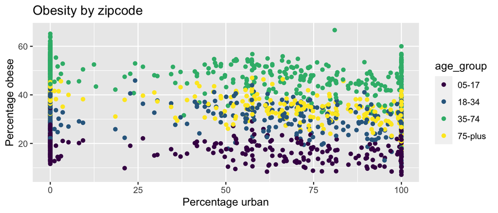

```r
edit2<-edit2%>%
  left_join(ru_b,by="zip")

ggplot(data=edit2,aes(x=100*p_urban,y=100*obese_p,color=age_group))+
  geom_point()+
  xlab("Percentage urban")+
  ylab("Percentage obese")+
  ggtitle("Obesity by zipcode")
```